# Risk Factor Analysis

## Outcome Variable

**Outcome Variable:** whz

## Predictor Variables

**Intervention Variable:** mbmi

**Adjustment Set:**

- arm
- W_mage
- W_fage
- meducyrs
- feducyrs
- single
- brthmon
- delta_W_mage
- delta_W_fage
- delta_meducyrs
- delta_feducyrs
- delta_single
- delta_brthmon

## Stratifying Variables

The analysis was stratified on these variable(s):

- agecat
- studyid
- country

## Data Summary

| agecat | studyid | country | mbmi | n_cell | n |
| --- | --- | --- | --- | --- | --- |
| Birth | ki0047075b-MAL-ED | BANGLADESH | Normal weight | 205 | 233 |
| Birth | ki0047075b-MAL-ED | BANGLADESH | Underweight | 28 | 233 |
| Birth | ki0047075b-MAL-ED | BRAZIL | Normal weight | 167 | 176 |
| Birth | ki0047075b-MAL-ED | BRAZIL | Underweight | 9 | 176 |
| Birth | ki0047075b-MAL-ED | INDIA | Normal weight | 157 | 195 |
| Birth | ki0047075b-MAL-ED | INDIA | Underweight | 38 | 195 |
| Birth | ki0047075b-MAL-ED | NEPAL | Normal weight | 167 | 167 |
| Birth | ki0047075b-MAL-ED | NEPAL | Underweight | 0 | 167 |
| Birth | ki0047075b-MAL-ED | PERU | Normal weight | 264 | 269 |
| Birth | ki0047075b-MAL-ED | PERU | Underweight | 5 | 269 |
| Birth | ki0047075b-MAL-ED | SOUTH AFRICA | Normal weight | 221 | 226 |
| Birth | ki0047075b-MAL-ED | SOUTH AFRICA | Underweight | 5 | 226 |
| Birth | ki0047075b-MAL-ED | TANZANIA, UNITED REPUBLIC OF | Normal weight | 109 | 116 |
| Birth | ki0047075b-MAL-ED | TANZANIA, UNITED REPUBLIC OF | Underweight | 7 | 116 |
| Birth | ki1000304b-SAS-CompFeed | INDIA | Normal weight | 77 | 110 |
| Birth | ki1000304b-SAS-CompFeed | INDIA | Underweight | 33 | 110 |
| Birth | ki1017093-NIH-Birth | BANGLADESH | Normal weight | 23 | 28 |
| Birth | ki1017093-NIH-Birth | BANGLADESH | Underweight | 5 | 28 |
| Birth | ki1017093c-NIH-Crypto | BANGLADESH | Normal weight | 17 | 23 |
| Birth | ki1017093c-NIH-Crypto | BANGLADESH | Underweight | 6 | 23 |
| Birth | ki1119695-PROBIT | BELARUS | Normal weight | 13143 | 13664 |
| Birth | ki1119695-PROBIT | BELARUS | Underweight | 521 | 13664 |
| Birth | ki1126311-ZVITAMBO | ZIMBABWE | Normal weight | 8573 | 9029 |
| Birth | ki1126311-ZVITAMBO | ZIMBABWE | Underweight | 456 | 9029 |
| 6 months | ki0047075b-MAL-ED | BANGLADESH | Normal weight | 209 | 241 |
| 6 months | ki0047075b-MAL-ED | BANGLADESH | Underweight | 32 | 241 |
| 6 months | ki0047075b-MAL-ED | BRAZIL | Normal weight | 199 | 208 |
| 6 months | ki0047075b-MAL-ED | BRAZIL | Underweight | 9 | 208 |
| 6 months | ki0047075b-MAL-ED | INDIA | Normal weight | 186 | 235 |
| 6 months | ki0047075b-MAL-ED | INDIA | Underweight | 49 | 235 |

[output cut: 52 more lines]

The following strata were considered:

- agecat: 24 months, studyid: ki0047075b-MAL-ED, country: BANGLADESH
- agecat: 24 months, studyid: ki0047075b-MAL-ED, country: BRAZIL
- agecat: 24 months, studyid: ki0047075b-MAL-ED, country: INDIA
- agecat: 24 months, studyid: ki0047075b-MAL-ED, country: NEPAL
- agecat: 24 months, studyid: ki0047075b-MAL-ED, country: PERU
- agecat: 24 months, studyid: ki0047075b-MAL-ED, country: SOUTH AFRICA
- agecat: 24 months, studyid: ki0047075b-MAL-ED, country: TANZANIA, UNITED REPUBLIC OF
- agecat: 24 months, studyid: ki1017093-NIH-Birth, country: BANGLADESH
- agecat: 24 months, studyid: ki1017093b-PROVIDE, country: BANGLADESH
- agecat: 24 months, studyid: ki1017093c-NIH-Crypto, country: BANGLADESH
- agecat: 24 months, studyid: ki1066203-TanzaniaChild2, country: TANZANIA, UNITED REPUBLIC OF
- agecat: 24 months, studyid: ki1119695-PROBIT, country: BELARUS
- agecat: 24 months, studyid: ki1126311-ZVITAMBO, country: ZIMBABWE
- agecat: 24 months, studyid: ki1148112-LCNI-5, country: MALAWI
- agecat: 6 months, studyid: ki0047075b-MAL-ED, country: BANGLADESH
- agecat: 6 months, studyid: ki0047075b-MAL-ED, country: BRAZIL
- agecat: 6 months, studyid: ki0047075b-MAL-ED, country: INDIA
- agecat: 6 months, studyid: ki0047075b-MAL-ED, country: NEPAL
- agecat: 6 months, studyid: ki0047075b-MAL-ED, country: PERU
- agecat: 6 months, studyid: ki0047075b-MAL-ED, country: SOUTH AFRICA
- agecat: 6 months, studyid: ki0047075b-MAL-ED, country: TANZANIA, UNITED REPUBLIC OF
- agecat: 6 months, studyid: ki1000304b-SAS-CompFeed, country: INDIA
- agecat: 6 months, studyid: ki1017093-NIH-Birth, country: BANGLADESH
- agecat: 6 months, studyid: ki1017093b-PROVIDE, country: BANGLADESH
- agecat: 6 months, studyid: ki1017093c-NIH-Crypto, country: BANGLADESH
- agecat: 6 months, studyid: ki1066203-TanzaniaChild2, country: TANZANIA, UNITED REPUBLIC OF
- agecat: 6 months, studyid: ki1119695-PROBIT, country: BELARUS
- agecat: 6 months, studyid: ki1126311-ZVITAMBO, country: ZIMBABWE
- agecat: 6 months, studyid: ki1148112-LCNI-5, country: MALAWI
- agecat: Birth, studyid: ki0047075b-MAL-ED, country: BANGLADESH
- agecat: Birth, studyid: ki0047075b-MAL-ED, country: BRAZIL
- agecat: Birth, studyid: ki0047075b-MAL-ED, country: INDIA
- agecat: Birth, studyid: ki0047075b-MAL-ED, country: NEPAL
- agecat: Birth, studyid: ki0047075b-MAL-ED, country: PERU
- agecat: Birth, studyid: ki0047075b-MAL-ED, country: SOUTH AFRICA
- agecat: Birth, studyid: ki0047075b-MAL-ED, country: TANZANIA, UNITED REPUBLIC OF
- agecat: Birth, studyid: ki1000304b-SAS-CompFeed, country: INDIA
- agecat: Birth, studyid: ki1017093-NIH-Birth, country: BANGLADESH
- agecat: Birth, studyid: ki1017093c-NIH-Crypto, country: BANGLADESH
- agecat: Birth, studyid: ki1119695-PROBIT, country: BELARUS
- agecat: Birth, studyid: ki1126311-ZVITAMBO, country: ZIMBABWE

### Dropped Strata

Some strata were dropped due to rare outcomes:

- agecat: Birth, studyid: ki0047075b-MAL-ED, country: NEPAL
- agecat: 6 months, studyid: ki0047075b-MAL-ED, country: NEPAL
- agecat: 24 months, studyid: ki0047075b-MAL-ED, country: NEPAL
- agecat: 24 months, studyid: ki0047075b-MAL-ED, country: PERU
- agecat: 24 months, studyid: ki1066203-TanzaniaChild2, country: TANZANIA, UNITED REPUBLIC OF

## Methods Detail

We’re interested in the causal parameters $E[Y_a]$ for all values of $a \in \mathcal{A}$. These parameters represent the mean outcome if, possibly contrary to fact, we intervened to set all units to have $A=a$. Under the randomization and positivity assumptions, these are identified by the statistical parameters $\psi_a=E_W[E_{Y|A,W}(Y|A=a,W)]$. In addition, we’re interested in the mean of $Y$, $E[Y]$ under no intervention (the observed mean). We will estimate these parameters by using SuperLearner to fit the relevant likelihood factors – $E_{Y|A,W}(Y|A=a,W)$ and $p(A=a|W)$, and then updating our likelihood fit using a joint TMLE.

For unadjusted analyses ($W=\{\}$), initial likelihoods were estimated using Lrnr_glm to estimate the simple $E(Y|A)$ and Lrnr_mean to estimate $p(A)$. For adjusted analyses, a small library containing Lrnr_glmnet, Lrnr_xgboost, and Lrnr_mean was used.

Having estimated these parameters, we will then use the delta method to estimate relative risks and attributable risks relative to a prespecified baseline level of $A$.

# Results Detail

## Results Plots

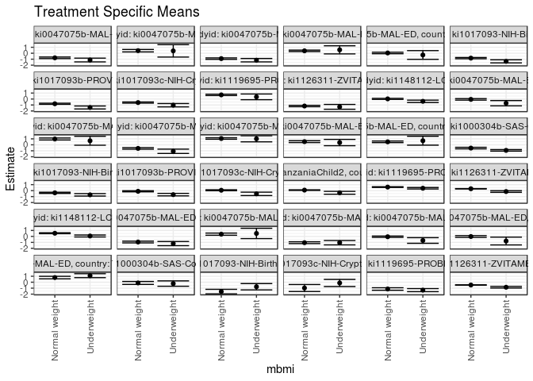

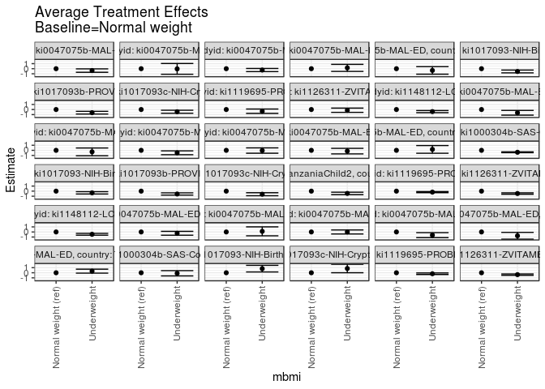

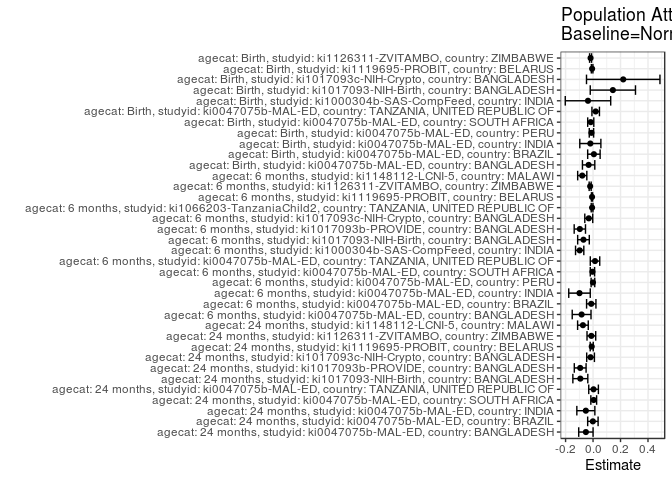

## Results Table

### Parameter: TSM

| agecat | studyid | country | intervention_level | baseline_level | estimate | ci_lower | ci_upper |
| --- | --- | --- | --- | --- | --- | --- | --- |
| Birth | ki0047075b-MAL-ED | BANGLADESH | Normal weight | NA | -0.9402171 | -1.0881356 | -0.7922986 |
| Birth | ki0047075b-MAL-ED | BANGLADESH | Underweight | NA | -1.2012616 | -1.5508803 | -0.8516430 |
| Birth | ki0047075b-MAL-ED | BRAZIL | Normal weight | NA | 0.3770060 | 0.1944840 | 0.5595280 |
| Birth | ki0047075b-MAL-ED | BRAZIL | Underweight | NA | 0.4988889 | -0.3650643 | 1.3628420 |
| Birth | ki0047075b-MAL-ED | INDIA | Normal weight | NA | -1.0501423 | -1.2057721 | -0.8945125 |
| Birth | ki0047075b-MAL-ED | INDIA | Underweight | NA | -1.0541515 | -1.4168728 | -0.6914302 |
| Birth | ki0047075b-MAL-ED | PERU | Normal weight | NA | -0.0544318 | -0.1690482 | 0.0601845 |
| Birth | ki0047075b-MAL-ED | PERU | Underweight | NA | -0.6820000 | -1.1578307 | -0.2061693 |
| Birth | ki0047075b-MAL-ED | SOUTH AFRICA | Normal weight | NA | -0.0178733 | -0.1685692 | 0.1328226 |
| Birth | ki0047075b-MAL-ED | SOUTH AFRICA | Underweight | NA | -0.7740000 | -1.4276053 | -0.1203947 |
| Birth | ki0047075b-MAL-ED | TANZANIA, UNITED REPUBLIC OF | Normal weight | NA | 0.7757798 | 0.5642184 | 0.9873412 |
| Birth | ki0047075b-MAL-ED | TANZANIA, UNITED REPUBLIC OF | Underweight | NA | 1.0942857 | 0.7651658 | 1.4234056 |
| Birth | ki1000304b-SAS-CompFeed | INDIA | Normal weight | NA | -0.1233291 | -0.3703545 | 0.1236964 |
| Birth | ki1000304b-SAS-CompFeed | INDIA | Underweight | NA | -0.2282736 | -0.6784630 | 0.2219158 |
| Birth | ki1017093-NIH-Birth | BANGLADESH | Normal weight | NA | -1.5682609 | -1.9461968 | -1.1903249 |
| Birth | ki1017093-NIH-Birth | BANGLADESH | Underweight | NA | -0.7600000 | -1.2890983 | -0.2309017 |
| Birth | ki1017093c-NIH-Crypto | BANGLADESH | Normal weight | NA | -0.9705882 | -1.5557317 | -0.3854448 |
| Birth | ki1017093c-NIH-Crypto | BANGLADESH | Underweight | NA | -0.1283333 | -0.7259906 | 0.4693239 |
| Birth | ki1119695-PROBIT | BELARUS | Normal weight | NA | -1.1373538 | -1.3476625 | -0.9270451 |
| Birth | ki1119695-PROBIT | BELARUS | Underweight | NA | -1.3276177 | -1.5852196 | -1.0700158 |
| Birth | ki1126311-ZVITAMBO | ZIMBABWE | Normal weight | NA | -0.4720194 | -0.5037683 | -0.4402705 |
| Birth | ki1126311-ZVITAMBO | ZIMBABWE | Underweight | NA | -0.8432817 | -0.9802008 | -0.7063626 |
| 6 months | ki0047075b-MAL-ED | BANGLADESH | Normal weight | NA | -0.0565939 | -0.1863889 | 0.0732011 |
| 6 months | ki0047075b-MAL-ED | BANGLADESH | Underweight | NA | -0.6995222 | -1.1447756 | -0.2542688 |
| 6 months | ki0047075b-MAL-ED | BRAZIL | Normal weight | NA | 0.9775209 | 0.8091090 | 1.1459329 |
| 6 months | ki0047075b-MAL-ED | BRAZIL | Underweight | NA | 0.6764815 | -0.0674862 | 1.4204491 |
| 6 months | ki0047075b-MAL-ED | INDIA | Normal weight | NA | -0.6001754 | -0.7311889 | -0.4691619 |
| 6 months | ki0047075b-MAL-ED | INDIA | Underweight | NA | -1.0838748 | -1.4404627 | -0.7272868 |
| 6 months | ki0047075b-MAL-ED | PERU | Normal weight | NA | 1.0571910 | 0.9326684 | 1.1817136 |
| 6 months | ki0047075b-MAL-ED | PERU | Underweight | NA | 1.0130000 | 0.5008674 | 1.5251326 |
| 6 months | ki0047075b-MAL-ED | SOUTH AFRICA | Normal weight | NA | 0.5333953 | 0.3757046 | 0.6910860 |
| 6 months | ki0047075b-MAL-ED | SOUTH AFRICA | Underweight | NA | 0.3785714 | -0.1478585 | 0.9050014 |
| 6 months | ki0047075b-MAL-ED | TANZANIA, UNITED REPUBLIC OF | Normal weight | NA | 0.5027558 | 0.3692936 | 0.6362180 |
| 6 months | ki0047075b-MAL-ED | TANZANIA, UNITED REPUBLIC OF | Underweight | NA | 0.6873727 | -0.0558766 | 1.4306221 |
| 6 months | ki1000304b-SAS-CompFeed | INDIA | Normal weight | NA | -0.5467905 | -0.6766870 | -0.4168940 |
| 6 months | ki1000304b-SAS-CompFeed | INDIA | Underweight | NA | -0.9297729 | -1.0580355 | -0.8015103 |
| 6 months | ki1017093-NIH-Birth | BANGLADESH | Normal weight | NA | -0.3692946 | -0.4667858 | -0.2718034 |
| 6 months | ki1017093-NIH-Birth | BANGLADESH | Underweight | NA | -0.7043867 | -0.9118071 | -0.4969664 |
| 6 months | ki1017093b-PROVIDE | BANGLADESH | Normal weight | NA | -0.1118528 | -0.2033924 | -0.0203133 |
| 6 months | ki1017093b-PROVIDE | BANGLADESH | Underweight | NA | -0.6738422 | -0.8811715 | -0.4665128 |
| 6 months | ki1017093c-NIH-Crypto | BANGLADESH | Normal weight | NA | 0.0609096 | -0.0209555 | 0.1427748 |
| 6 months | ki1017093c-NIH-Crypto | BANGLADESH | Underweight | NA | -0.5449143 | -0.8272968 | -0.2625318 |
| 6 months | ki1066203-TanzaniaChild2 | TANZANIA, UNITED REPUBLIC OF | Normal weight | NA | 0.0845608 | 0.0301118 | 0.1390099 |
| 6 months | ki1066203-TanzaniaChild2 | TANZANIA, UNITED REPUBLIC OF | Underweight | NA | -0.3663256 | -0.6047968 | -0.1278544 |
| 6 months | ki1119695-PROBIT | BELARUS | Normal weight | NA | 0.5904031 | 0.5326254 | 0.6481808 |
| 6 months | ki1119695-PROBIT | BELARUS | Underweight | NA | 0.4000200 | 0.2735538 | 0.5264862 |
| 6 months | ki1126311-ZVITAMBO | ZIMBABWE | Normal weight | NA | 0.3138238 | 0.2852600 | 0.3423876 |
| 6 months | ki1126311-ZVITAMBO | ZIMBABWE | Underweight | NA | -0.1525531 | -0.2909785 | -0.0141276 |
| 6 months | ki1148112-LCNI-5 | MALAWI | Normal weight | NA | 0.5301533 | 0.4517641 | 0.6085426 |
| 6 months | ki1148112-LCNI-5 | MALAWI | Underweight | NA | 0.0707443 | -0.0938992 | 0.2353878 |
| 24 months | ki0047075b-MAL-ED | BANGLADESH | Normal weight | NA | -0.7687055 | -0.8993638 | -0.6380472 |
| 24 months | ki0047075b-MAL-ED | BANGLADESH | Underweight | NA | -1.1350033 | -1.4489478 | -0.8210589 |
| 24 months | ki0047075b-MAL-ED | BRAZIL | Normal weight | NA | 0.4294444 | 0.2224555 | 0.6364334 |
| 24 months | ki0047075b-MAL-ED | BRAZIL | Underweight | NA | 0.3966667 | -0.6451983 | 1.4385316 |
| 24 months | ki0047075b-MAL-ED | INDIA | Normal weight | NA | -0.9001636 | -1.0245612 | -0.7757660 |
| 24 months | ki0047075b-MAL-ED | INDIA | Underweight | NA | -1.1644128 | -1.4508798 | -0.8779458 |
| 24 months | ki0047075b-MAL-ED | SOUTH AFRICA | Normal weight | NA | 0.4046696 | 0.2835400 | 0.5257992 |
| 24 months | ki0047075b-MAL-ED | SOUTH AFRICA | Underweight | NA | 0.5700000 | -0.1123856 | 1.2523856 |
| 24 months | ki0047075b-MAL-ED | TANZANIA, UNITED REPUBLIC OF | Normal weight | NA | 0.0463702 | -0.0807160 | 0.1734564 |
| 24 months | ki0047075b-MAL-ED | TANZANIA, UNITED REPUBLIC OF | Underweight | NA | -0.2912768 | -1.0235277 | 0.4409740 |
| 24 months | ki1017093-NIH-Birth | BANGLADESH | Normal weight | NA | -0.8190587 | -0.9223082 | -0.7158092 |
| 24 months | ki1017093-NIH-Birth | BANGLADESH | Underweight | NA | -1.3604298 | -1.6207155 | -1.1001440 |
| 24 months | ki1017093b-PROVIDE | BANGLADESH | Normal weight | NA | -0.7929181 | -0.8843010 | -0.7015352 |
| 24 months | ki1017093b-PROVIDE | BANGLADESH | Underweight | NA | -1.4182007 | -1.6682844 | -1.1681170 |
| 24 months | ki1017093c-NIH-Crypto | BANGLADESH | Normal weight | NA | -0.5922152 | -0.6914928 | -0.4929376 |
| 24 months | ki1017093c-NIH-Crypto | BANGLADESH | Underweight | NA | -1.0345017 | -1.3133919 | -0.7556116 |
| 24 months | ki1119695-PROBIT | BELARUS | Normal weight | NA | 0.6966291 | 0.5862128 | 0.8070453 |
| 24 months | ki1119695-PROBIT | BELARUS | Underweight | NA | 0.3620490 | -0.1186636 | 0.8427616 |
| 24 months | ki1126311-ZVITAMBO | ZIMBABWE | Normal weight | NA | -1.1687223 | -1.2828153 | -1.0546294 |
| 24 months | ki1126311-ZVITAMBO | ZIMBABWE | Underweight | NA | -1.3104325 | -1.7135573 | -0.9073078 |
| 24 months | ki1148112-LCNI-5 | MALAWI | Normal weight | NA | 0.0266481 | -0.0634386 | 0.1167348 |
| 24 months | ki1148112-LCNI-5 | MALAWI | Underweight | NA | -0.3847146 | -0.5816258 | -0.1878034 |

### Parameter: E(Y)

| agecat | studyid | country | intervention_level | baseline_level | estimate | ci_lower | ci_upper |
| --- | --- | --- | --- | --- | --- | --- | --- |
| Birth | ki0047075b-MAL-ED | BANGLADESH | NA | NA | -0.9724464 | -1.1091046 | -0.8357881 |
| Birth | ki0047075b-MAL-ED | BRAZIL | NA | NA | 0.3832386 | 0.2044597 | 0.5620175 |
| Birth | ki0047075b-MAL-ED | INDIA | NA | NA | -1.0698974 | -1.2115847 | -0.9282102 |
| Birth | ki0047075b-MAL-ED | PERU | NA | NA | -0.0660967 | -0.1789362 | 0.0467429 |
| Birth | ki0047075b-MAL-ED | SOUTH AFRICA | NA | NA | -0.0346018 | -0.1831486 | 0.1139451 |
| Birth | ki0047075b-MAL-ED | TANZANIA, UNITED REPUBLIC OF | NA | NA | 0.7950000 | 0.5947353 | 0.9952647 |
| Birth | ki1000304b-SAS-CompFeed | INDIA | NA | NA | -0.1601818 | -0.3763991 | 0.0560355 |
| Birth | ki1017093-NIH-Birth | BANGLADESH | NA | NA | -1.4239286 | -1.7688028 | -1.0790544 |
| Birth | ki1017093c-NIH-Crypto | BANGLADESH | NA | NA | -0.7508696 | -1.2358912 | -0.2658480 |
| Birth | ki1119695-PROBIT | BELARUS | NA | NA | -1.1441269 | -1.3547476 | -0.9335062 |
| Birth | ki1126311-ZVITAMBO | ZIMBABWE | NA | NA | -0.4900343 | -0.5209436 | -0.4591251 |
| 6 months | ki0047075b-MAL-ED | BANGLADESH | NA | NA | -0.1397960 | -0.2688682 | -0.0107238 |
| 6 months | ki0047075b-MAL-ED | BRAZIL | NA | NA | 0.9644952 | 0.7999744 | 1.1290160 |
| 6 months | ki0047075b-MAL-ED | INDIA | NA | NA | -0.6987943 | -0.8241325 | -0.5734561 |
| 6 months | ki0047075b-MAL-ED | PERU | NA | NA | 1.0563787 | 0.9342938 | 1.1784635 |
| 6 months | ki0047075b-MAL-ED | SOUTH AFRICA | NA | NA | 0.5290428 | 0.3750394 | 0.6830463 |
| 6 months | ki0047075b-MAL-ED | TANZANIA, UNITED REPUBLIC OF | NA | NA | 0.5170513 | 0.3872178 | 0.6468847 |
| 6 months | ki1000304b-SAS-CompFeed | INDIA | NA | NA | -0.6441020 | -0.7710827 | -0.5171213 |
| 6 months | ki1017093-NIH-Birth | BANGLADESH | NA | NA | -0.4389101 | -0.5279432 | -0.3498771 |
| 6 months | ki1017093b-PROVIDE | BANGLADESH | NA | NA | -0.2079891 | -0.2925599 | -0.1234183 |
| 6 months | ki1017093c-NIH-Crypto | BANGLADESH | NA | NA | 0.0297622 | -0.0491685 | 0.1086930 |
| 6 months | ki1066203-TanzaniaChild2 | TANZANIA, UNITED REPUBLIC OF | NA | NA | 0.0775172 | 0.0241750 | 0.1308595 |
| 6 months | ki1119695-PROBIT | BELARUS | NA | NA | 0.5829956 | 0.5247249 | 0.6412663 |
| 6 months | ki1126311-ZVITAMBO | ZIMBABWE | NA | NA | 0.2928094 | 0.2648167 | 0.3208020 |
| 6 months | ki1148112-LCNI-5 | MALAWI | NA | NA | 0.4515431 | 0.3802415 | 0.5228446 |
| 24 months | ki0047075b-MAL-ED | BANGLADESH | NA | NA | -0.8208255 | -0.9429246 | -0.6987264 |
| 24 months | ki0047075b-MAL-ED | BRAZIL | NA | NA | 0.4282738 | 0.2252365 | 0.6313111 |
| 24 months | ki0047075b-MAL-ED | INDIA | NA | NA | -0.9525664 | -1.0684455 | -0.8366872 |
| 24 months | ki0047075b-MAL-ED | SOUTH AFRICA | NA | NA | 0.4096154 | 0.2902946 | 0.5289362 |
| 24 months | ki0047075b-MAL-ED | TANZANIA, UNITED REPUBLIC OF | NA | NA | 0.0500935 | -0.0748234 | 0.1750103 |
| 24 months | ki1017093-NIH-Birth | BANGLADESH | NA | NA | -0.9115790 | -1.0095022 | -0.8136559 |
| 24 months | ki1017093b-PROVIDE | BANGLADESH | NA | NA | -0.8864991 | -0.9695215 | -0.8034768 |
| 24 months | ki1017093c-NIH-Crypto | BANGLADESH | NA | NA | -0.6103502 | -0.7050157 | -0.5156847 |
| 24 months | ki1119695-PROBIT | BELARUS | NA | NA | 0.6869754 | 0.5725638 | 0.8013869 |
| 24 months | ki1126311-ZVITAMBO | ZIMBABWE | NA | NA | -1.1810028 | -1.2914599 | -1.0705456 |
| 24 months | ki1148112-LCNI-5 | MALAWI | NA | NA | -0.0469519 | -0.1290932 | 0.0351895 |

### Parameter: ATE

| agecat | studyid | country | intervention_level | baseline_level | estimate | ci_lower | ci_upper |
| --- | --- | --- | --- | --- | --- | --- | --- |
| Birth | ki0047075b-MAL-ED | BANGLADESH | Normal weight | Normal weight | 0.0000000 | 0.0000000 | 0.0000000 |
| Birth | ki0047075b-MAL-ED | BANGLADESH | Underweight | Normal weight | -0.2610445 | -0.6399575 | 0.1178684 |
| Birth | ki0047075b-MAL-ED | BRAZIL | Normal weight | Normal weight | 0.0000000 | 0.0000000 | 0.0000000 |
| Birth | ki0047075b-MAL-ED | BRAZIL | Underweight | Normal weight | 0.1218829 | -0.7611399 | 1.0049057 |
| Birth | ki0047075b-MAL-ED | INDIA | Normal weight | Normal weight | 0.0000000 | 0.0000000 | 0.0000000 |
| Birth | ki0047075b-MAL-ED | INDIA | Underweight | Normal weight | -0.0040092 | -0.4006688 | 0.3926503 |
| Birth | ki0047075b-MAL-ED | PERU | Normal weight | Normal weight | 0.0000000 | 0.0000000 | 0.0000000 |
| Birth | ki0047075b-MAL-ED | PERU | Underweight | Normal weight | -0.6275682 | -1.1170084 | -0.1381280 |
| Birth | ki0047075b-MAL-ED | SOUTH AFRICA | Normal weight | Normal weight | 0.0000000 | 0.0000000 | 0.0000000 |
| Birth | ki0047075b-MAL-ED | SOUTH AFRICA | Underweight | Normal weight | -0.7561267 | -1.4268793 | -0.0853741 |
| Birth | ki0047075b-MAL-ED | TANZANIA, UNITED REPUBLIC OF | Normal weight | Normal weight | 0.0000000 | 0.0000000 | 0.0000000 |
| Birth | ki0047075b-MAL-ED | TANZANIA, UNITED REPUBLIC OF | Underweight | Normal weight | 0.3185059 | -0.0727461 | 0.7097579 |
| Birth | ki1000304b-SAS-CompFeed | INDIA | Normal weight | Normal weight | 0.0000000 | 0.0000000 | 0.0000000 |
| Birth | ki1000304b-SAS-CompFeed | INDIA | Underweight | Normal weight | -0.1049445 | -0.6239766 | 0.4140876 |
| Birth | ki1017093-NIH-Birth | BANGLADESH | Normal weight | Normal weight | 0.0000000 | 0.0000000 | 0.0000000 |
| Birth | ki1017093-NIH-Birth | BANGLADESH | Underweight | Normal weight | 0.8082609 | 0.1580450 | 1.4584767 |
| Birth | ki1017093c-NIH-Crypto | BANGLADESH | Normal weight | Normal weight | 0.0000000 | 0.0000000 | 0.0000000 |
| Birth | ki1017093c-NIH-Crypto | BANGLADESH | Underweight | Normal weight | 0.8422549 | 0.0058417 | 1.6786681 |
| Birth | ki1119695-PROBIT | BELARUS | Normal weight | Normal weight | 0.0000000 | 0.0000000 | 0.0000000 |
| Birth | ki1119695-PROBIT | BELARUS | Underweight | Normal weight | -0.1902639 | -0.3439228 | -0.0366049 |
| Birth | ki1126311-ZVITAMBO | ZIMBABWE | Normal weight | Normal weight | 0.0000000 | 0.0000000 | 0.0000000 |
| Birth | ki1126311-ZVITAMBO | ZIMBABWE | Underweight | Normal weight | -0.3712624 | -0.5118490 | -0.2306757 |
| 6 months | ki0047075b-MAL-ED | BANGLADESH | Normal weight | Normal weight | 0.0000000 | 0.0000000 | 0.0000000 |
| 6 months | ki0047075b-MAL-ED | BANGLADESH | Underweight | Normal weight | -0.6429283 | -1.1070345 | -0.1788220 |
| 6 months | ki0047075b-MAL-ED | BRAZIL | Normal weight | Normal weight | 0.0000000 | 0.0000000 | 0.0000000 |
| 6 months | ki0047075b-MAL-ED | BRAZIL | Underweight | Normal weight | -0.3010395 | -1.0638307 | 0.4617517 |
| 6 months | ki0047075b-MAL-ED | INDIA | Normal weight | Normal weight | 0.0000000 | 0.0000000 | 0.0000000 |
| 6 months | ki0047075b-MAL-ED | INDIA | Underweight | Normal weight | -0.4836994 | -0.8631726 | -0.1042262 |
| 6 months | ki0047075b-MAL-ED | PERU | Normal weight | Normal weight | 0.0000000 | 0.0000000 | 0.0000000 |
| 6 months | ki0047075b-MAL-ED | PERU | Underweight | Normal weight | -0.0441910 | -0.5712448 | 0.4828628 |
| 6 months | ki0047075b-MAL-ED | SOUTH AFRICA | Normal weight | Normal weight | 0.0000000 | 0.0000000 | 0.0000000 |
| 6 months | ki0047075b-MAL-ED | SOUTH AFRICA | Underweight | Normal weight | -0.1548239 | -0.7043645 | 0.3947167 |
| 6 months | ki0047075b-MAL-ED | TANZANIA, UNITED REPUBLIC OF | Normal weight | Normal weight | 0.0000000 | 0.0000000 | 0.0000000 |
| 6 months | ki0047075b-MAL-ED | TANZANIA, UNITED REPUBLIC OF | Underweight | Normal weight | 0.1846169 | -0.5743896 | 0.9436234 |
| 6 months | ki1000304b-SAS-CompFeed | INDIA | Normal weight | Normal weight | 0.0000000 | 0.0000000 | 0.0000000 |
| 6 months | ki1000304b-SAS-CompFeed | INDIA | Underweight | Normal weight | -0.3829824 | -0.4679009 | -0.2980639 |
| 6 months | ki1017093-NIH-Birth | BANGLADESH | Normal weight | Normal weight | 0.0000000 | 0.0000000 | 0.0000000 |
| 6 months | ki1017093-NIH-Birth | BANGLADESH | Underweight | Normal weight | -0.3350921 | -0.5653203 | -0.1048638 |
| 6 months | ki1017093b-PROVIDE | BANGLADESH | Normal weight | Normal weight | 0.0000000 | 0.0000000 | 0.0000000 |
| 6 months | ki1017093b-PROVIDE | BANGLADESH | Underweight | Normal weight | -0.5619893 | -0.7884155 | -0.3355631 |
| 6 months | ki1017093c-NIH-Crypto | BANGLADESH | Normal weight | Normal weight | 0.0000000 | 0.0000000 | 0.0000000 |
| 6 months | ki1017093c-NIH-Crypto | BANGLADESH | Underweight | Normal weight | -0.6058240 | -0.9003196 | -0.3113284 |
| 6 months | ki1066203-TanzaniaChild2 | TANZANIA, UNITED REPUBLIC OF | Normal weight | Normal weight | 0.0000000 | 0.0000000 | 0.0000000 |
| 6 months | ki1066203-TanzaniaChild2 | TANZANIA, UNITED REPUBLIC OF | Underweight | Normal weight | -0.4508864 | -0.6954076 | -0.2063652 |
| 6 months | ki1119695-PROBIT | BELARUS | Normal weight | Normal weight | 0.0000000 | 0.0000000 | 0.0000000 |
| 6 months | ki1119695-PROBIT | BELARUS | Underweight | Normal weight | -0.1903831 | -0.3007109 | -0.0800552 |
| 6 months | ki1126311-ZVITAMBO | ZIMBABWE | Normal weight | Normal weight | 0.0000000 | 0.0000000 | 0.0000000 |
| 6 months | ki1126311-ZVITAMBO | ZIMBABWE | Underweight | Normal weight | -0.4663769 | -0.6076621 | -0.3250917 |
| 6 months | ki1148112-LCNI-5 | MALAWI | Normal weight | Normal weight | 0.0000000 | 0.0000000 | 0.0000000 |
| 6 months | ki1148112-LCNI-5 | MALAWI | Underweight | Normal weight | -0.4594090 | -0.6418851 | -0.2769330 |
| 24 months | ki0047075b-MAL-ED | BANGLADESH | Normal weight | Normal weight | 0.0000000 | 0.0000000 | 0.0000000 |
| 24 months | ki0047075b-MAL-ED | BANGLADESH | Underweight | Normal weight | -0.3662978 | -0.7060895 | -0.0265062 |
| 24 months | ki0047075b-MAL-ED | BRAZIL | Normal weight | Normal weight | 0.0000000 | 0.0000000 | 0.0000000 |
| 24 months | ki0047075b-MAL-ED | BRAZIL | Underweight | Normal weight | -0.0327778 | -1.0950051 | 1.0294496 |
| 24 months | ki0047075b-MAL-ED | INDIA | Normal weight | Normal weight | 0.0000000 | 0.0000000 | 0.0000000 |
| 24 months | ki0047075b-MAL-ED | INDIA | Underweight | Normal weight | -0.2642492 | -0.5767289 | 0.0482306 |
| 24 months | ki0047075b-MAL-ED | SOUTH AFRICA | Normal weight | Normal weight | 0.0000000 | 0.0000000 | 0.0000000 |
| 24 months | ki0047075b-MAL-ED | SOUTH AFRICA | Underweight | Normal weight | 0.1653304 | -0.5277226 | 0.8583834 |
| 24 months | ki0047075b-MAL-ED | TANZANIA, UNITED REPUBLIC OF | Normal weight | Normal weight | 0.0000000 | 0.0000000 | 0.0000000 |
| 24 months | ki0047075b-MAL-ED | TANZANIA, UNITED REPUBLIC OF | Underweight | Normal weight | -0.3376470 | -1.0805035 | 0.4052094 |
| 24 months | ki1017093-NIH-Birth | BANGLADESH | Normal weight | Normal weight | 0.0000000 | 0.0000000 | 0.0000000 |
| 24 months | ki1017093-NIH-Birth | BANGLADESH | Underweight | Normal weight | -0.5413711 | -0.8211099 | -0.2616322 |
| 24 months | ki1017093b-PROVIDE | BANGLADESH | Normal weight | Normal weight | 0.0000000 | 0.0000000 | 0.0000000 |
| 24 months | ki1017093b-PROVIDE | BANGLADESH | Underweight | Normal weight | -0.6252826 | -0.8912595 | -0.3593057 |
| 24 months | ki1017093c-NIH-Crypto | BANGLADESH | Normal weight | Normal weight | 0.0000000 | 0.0000000 | 0.0000000 |
| 24 months | ki1017093c-NIH-Crypto | BANGLADESH | Underweight | Normal weight | -0.4422865 | -0.7391413 | -0.1454318 |
| 24 months | ki1119695-PROBIT | BELARUS | Normal weight | Normal weight | 0.0000000 | 0.0000000 | 0.0000000 |
| 24 months | ki1119695-PROBIT | BELARUS | Underweight | Normal weight | -0.3345801 | -0.7671552 | 0.0979951 |
| 24 months | ki1126311-ZVITAMBO | ZIMBABWE | Normal weight | Normal weight | 0.0000000 | 0.0000000 | 0.0000000 |
| 24 months | ki1126311-ZVITAMBO | ZIMBABWE | Underweight | Normal weight | -0.1417102 | -0.5607518 | 0.2773314 |
| 24 months | ki1148112-LCNI-5 | MALAWI | Normal weight | Normal weight | 0.0000000 | 0.0000000 | 0.0000000 |
| 24 months | ki1148112-LCNI-5 | MALAWI | Underweight | Normal weight | -0.4113627 | -0.6279490 | -0.1947764 |

### Parameter: PAR

| agecat | studyid | country | intervention_level | baseline_level | estimate | ci_lower | ci_upper |
| --- | --- | --- | --- | --- | --- | --- | --- |
| Birth | ki0047075b-MAL-ED | BANGLADESH | Normal weight | NA | -0.0322293 | -0.0772133 | 0.0127548 |
| Birth | ki0047075b-MAL-ED | BRAZIL | Normal weight | NA | 0.0062326 | -0.0390968 | 0.0515621 |
| Birth | ki0047075b-MAL-ED | INDIA | Normal weight | NA | -0.0197551 | -0.0964981 | 0.0569878 |
| Birth | ki0047075b-MAL-ED | PERU | Normal weight | NA | -0.0116648 | -0.0275614 | 0.0042317 |
| Birth | ki0047075b-MAL-ED | SOUTH AFRICA | Normal weight | NA | -0.0167285 | -0.0389179 | 0.0054610 |
| Birth | ki0047075b-MAL-ED | TANZANIA, UNITED REPUBLIC OF | Normal weight | NA | 0.0192202 | -0.0081584 | 0.0465987 |
| Birth | ki1000304b-SAS-CompFeed | INDIA | Normal weight | NA | -0.0368528 | -0.2022097 | 0.1285042 |
| Birth | ki1017093-NIH-Birth | BANGLADESH | Normal weight | NA | 0.1443323 | -0.0203351 | 0.3089996 |
| Birth | ki1017093c-NIH-Crypto | BANGLADESH | Normal weight | NA | 0.2197187 | -0.0476628 | 0.4871001 |
| Birth | ki1119695-PROBIT | BELARUS | Normal weight | NA | -0.0067731 | -0.0124825 | -0.0010637 |
| Birth | ki1126311-ZVITAMBO | ZIMBABWE | Normal weight | NA | -0.0180150 | -0.0251544 | -0.0108755 |
| 6 months | ki0047075b-MAL-ED | BANGLADESH | Normal weight | NA | -0.0832021 | -0.1515903 | -0.0148139 |
| 6 months | ki0047075b-MAL-ED | BRAZIL | Normal weight | NA | -0.0130257 | -0.0470695 | 0.0210180 |
| 6 months | ki0047075b-MAL-ED | INDIA | Normal weight | NA | -0.0986189 | -0.1769558 | -0.0202820 |
| 6 months | ki0047075b-MAL-ED | PERU | Normal weight | NA | -0.0008123 | -0.0140076 | 0.0123830 |
| 6 months | ki0047075b-MAL-ED | SOUTH AFRICA | Normal weight | NA | -0.0043525 | -0.0201263 | 0.0114214 |
| 6 months | ki0047075b-MAL-ED | TANZANIA, UNITED REPUBLIC OF | Normal weight | NA | 0.0142955 | -0.0200291 | 0.0486201 |
| 6 months | ki1000304b-SAS-CompFeed | INDIA | Normal weight | NA | -0.0973115 | -0.1274014 | -0.0672217 |
| 6 months | ki1017093-NIH-Birth | BANGLADESH | Normal weight | NA | -0.0696155 | -0.1119150 | -0.0273160 |
| 6 months | ki1017093b-PROVIDE | BANGLADESH | Normal weight | NA | -0.0961363 | -0.1373240 | -0.0549485 |
| 6 months | ki1017093c-NIH-Crypto | BANGLADESH | Normal weight | NA | -0.0311474 | -0.0600751 | -0.0022197 |
| 6 months | ki1066203-TanzaniaChild2 | TANZANIA, UNITED REPUBLIC OF | Normal weight | NA | -0.0070436 | -0.0132881 | -0.0007991 |
| 6 months | ki1119695-PROBIT | BELARUS | Normal weight | NA | -0.0074075 | -0.0116526 | -0.0031623 |
| 6 months | ki1126311-ZVITAMBO | ZIMBABWE | Normal weight | NA | -0.0210144 | -0.0282562 | -0.0137726 |
| 6 months | ki1148112-LCNI-5 | MALAWI | Normal weight | NA | -0.0786103 | -0.1119079 | -0.0453127 |
| 24 months | ki0047075b-MAL-ED | BANGLADESH | Normal weight | NA | -0.0521200 | -0.1044430 | 0.0002030 |
| 24 months | ki0047075b-MAL-ED | BRAZIL | Normal weight | NA | -0.0011706 | -0.0391185 | 0.0367773 |
| 24 months | ki0047075b-MAL-ED | INDIA | Normal weight | NA | -0.0524028 | -0.1179943 | 0.0131888 |
| 24 months | ki0047075b-MAL-ED | SOUTH AFRICA | Normal weight | NA | 0.0049458 | -0.0160996 | 0.0259912 |
| 24 months | ki0047075b-MAL-ED | TANZANIA, UNITED REPUBLIC OF | Normal weight | NA | 0.0037233 | -0.0313898 | 0.0388364 |
| 24 months | ki1017093-NIH-Birth | BANGLADESH | Normal weight | NA | -0.0925204 | -0.1469201 | -0.0381206 |
| 24 months | ki1017093b-PROVIDE | BANGLADESH | Normal weight | NA | -0.0935810 | -0.1364939 | -0.0506682 |
| 24 months | ki1017093c-NIH-Crypto | BANGLADESH | Normal weight | NA | -0.0181350 | -0.0462083 | 0.0099383 |
| 24 months | ki1119695-PROBIT | BELARUS | Normal weight | NA | -0.0096537 | -0.0208007 | 0.0014933 |
| 24 months | ki1126311-ZVITAMBO | ZIMBABWE | Normal weight | NA | -0.0122805 | -0.0438881 | 0.0193271 |
| 24 months | ki1148112-LCNI-5 | MALAWI | Normal weight | NA | -0.0736000 | -0.1123991 | -0.0348008 |